# Single Cell RNASeq analysis walkthrough

# 1 Code conventions

Most of the code below is meant to be entered at the R console, and is annotated like this:

```r
# Code formatted like this should be pasted into an R session
print("hello world")
```

A few code snippets will need to be entered at the command line (or “Terminal”). Command line code is annotated like this:

```bash
# this is code to be entered at the command line
echo Hello world
```

# 2 Prerequisites

This document provides a guided analysis of a scRNASeq dataset. The only pre-requisites are access to a “well formed” computer/server with R installed. By “well formed” I mean that the computer you are working on will need the usual GNU toolchain and related tools (gcc, gfortran, libssl, hdf5 libraries, etc). MacOS uses clang and that toolchain is fine too.

## 2.1 Ubuntu and other Linux distros

From a fresh installation of Ubuntu 18.04, the following will ensure the requisite tools are installed. For other flavors of Linux, the steps should be analogous, though not necessarily exactly the same depending on which packaging system you are using.

```bash
# switch to root shell
sudo -s

# install build tools
apt update
apt install -y build-essential
apt intall -y gfortran

# The version of R in the ubuntu releases always lags, so we need to add
# the R-project repository, get its security key, and then install R

# a little shell magic to get our Ubuntu release's "codename"
RELEASE=$(lsb_release -as 2>/dev/null | tail -n1)

echo "deb https://cloud.r-project.org/bin/linux/ubuntu ${RELEASE}-cran40/" >> /etc/apt/sources.list
apt-key adv --keyserver keyserver.ubuntu.com --recv-keys 51716619E084DAB9
apt  update
apt -y install r-base

# the packages we will need have some system level dependencies.
# so we will install those
apt -y install libssl-dev
apt -y install libcurl4-openssl-dev
apt -y install libxml2-dev
```

Verify your R version is >= 4.0.2 as follow:

```bash
R --version
```

## 2.2 MacOS

The clang environment provided by Apple should include all the dependencies you need except for gfortran which must be installed separately.

To see if you have these tools installed, open a terminal window and enter the following commands.

```bash
clang -v
gfortran -v
```

If that returns a version (like `Apple clang version 11.0.0` and `gcc version 8.2.0 (GCC)`), you should be all set.

If clang is not found, run the following from the command line:

```bash
xcode-select --install
```

If gfortran is not found, [download and install it from here](https://github.com/fxcoudert/gfortran-for-macOS/releases/tag/8.2). (Open the disk image, then open the (‘gfortran-8.2-Mojave’ folder and double click the “gfortran.pkg” item to run the installer).

If you have not already done so, download and install R and (highly recommended) RStudio according to the directions [here](https://rstudio.com/products/rstudio/download/#download).

## 2.3 Windows

Windows binaries for the necessary tools should be available from CRAN, so simply download and install R and (highly recommended) RStudio according to the directions [here](https://rstudio.com/products/rstudio/download/#download).

You will not be able to build source-only packages with this setup. But you can easily install the additional tools needed for building R packages (and even R itself) on your Windows box. The R team very helpfully provides the necessary software (based on gcc, mingw, and msys) and instructions for building R and its packages from source (see instructions [here](https://cran.r-project.org/bin/windows/Rtools)).

**Note that you do not need to build R from source**, you just need these tools installed and configured as explained at the link above there to build packages from source. In particular, there is currently a conflict between the `cpp11` package and the `tidyr` package that requires building the latest `cpp11` version on github from source (see below) in order to install `tidyr` (required by Seurat and, I assume, Monocle as well).

# 3 Installing analysis tools

## 3.1 Installing Seurat

We will be using the Seurat and Monocle (version 3) packages for the analyses here. Seurat is available on CRAN so installation should be easy. Try the following. If it fails, read the next section.

```r
install.packages('Seurat')
```

## 3.2 If Seurat installation fails

While installing Seurat should be easy, at the moment there is a conflict between the latest release version of the `cpp11` and `tidyr` (on which Seurat depends). So we need to do a little work around.to install the development version of `cpp11` that fixes that. **Note:** This requires building from source, so you will need to have gcc or clang or mingw/msys (Window) installed. See additional notes in the prerequisites section above.

```r
if (!requireNamespace("devtools", quietly = TRUE))
  install.packages("devtools")
devtools::install_github("r-lib/cpp11")
install.packages('Seurat')
```

## 3.3 Installing Monocle3

The latest Monocle must be installed from github, and has some pre-requisites that must be installed. The pre-requisites are part of the Bioconductor project so we will add the Bioconductor repositories to the list of searched repositories when installing packages.

```r
setRepositories(ind=1:6)
install.packages(c('BiocGenerics', 'DelayedArray', 'DelayedMatrixStats',
                       'limma', 'S4Vectors', 'SingleCellExperiment',
                       'SummarizedExperiment', 'batchelor', 'Matrix.utils'))

# install leidenbase and monocle3 from github
if (!requireNamespace("devtools", quietly = TRUE))
  install.packages("devtools")

# install_github will error out if installed binary packages were built under
# version of R newer than what we have locally. Change setting to ignore these
# warnings.
Sys.setenv(R_REMOTES_NO_ERRORS_FROM_WARNINGS="true")

devtools::install_github('cole-trapnell-lab/leidenbase')
devtools::install_github('cole-trapnell-lab/monocle3')
```

# 4 Obtaining Dataset

For this walkthrough, you will need an example dataset from 10X Genomics. You can download that dataset (here)[https://cf.10xgenomics.com/samples/cell/pbmc3k/pbmc3k_filtered_gene_bc_matrices.tar.gz] Decompress that file after you download it.

From the command line you can obtain the dataset and decompress it as follows:

```bash
# if you have wget installed
wget https://cf.10xgenomics.com/samples/cell/pbmc3k/pbmc3k_filtered_gene_bc_matrices.tar.gz

# if you don't
curl -o pbmc3k_filtered_gene_bc_matrices.tar.gz https://cf.10xgenomics.com/samples/cell/pbmc3k/pbmc3k_filtered_gene_bc_matrices.tar.gz

tar -zxvf pbmc3k_filtered_gene_bc_matrices.tar.gz
```

# 5 Loading data

Now that we have some data, we need to load it into a data object that can be used by Seurat or Monocle.

```r
# Seurat
pbmc.data <- Read10X(data.dir = "filtered_gene_bc_matrices/hg19/")
pbmc <- CreateSeuratObject(counts = pbmc.data, project = "pbmc3k", min.cells = 3, min.features = 200)

#monocle
cds <- load_mm_data(mat_path = "filtered_gene_bc_matrices/hg19/matrix.mtx",
                    feature_anno_path = "filtered_gene_bc_matrices/hg19/genes.tsv",
                    cell_anno_path = "filtered_gene_bc_matrices/hg19/barcodes.tsv")
colnames(rowData(cds)) <- "gene_short_name"

# this will fail if there are duplicate gene names
rownames(cds) <- rowData(cds)$gene_short_name

# filter as above
rc <- apply(counts(cds), 1, function(x) { sum(x > 0) })
cc <- apply(counts(cds), 2, function(x) { sum(x > 0) })
cds <- cds[which(rc >= 3), which(cc >= 200)]
```

You can also convert between the two formats.

```r
seuratToMonocle3 <- function(x, assay = NULL) {
  # based on as.CellDataSet function in Seurat, updated for Monocle3
  if(is.null(assay))
    assay <- DefaultAssay(x)

  counts <- GetAssayData(object = x, assay = assay, slot = "counts")
  cell_metadata <- x[[]]
  feature_metadata <- x[[assay]][[]]
  if (!"gene_short_name" %in% colnames(x = feature_metadata)) {
    feature_metadata$gene_short_name <- rownames(feature_metadata)
  }
  new_cell_data_set(counts,
                         cell_metadata = cell_metadata,
                         gene_metadata = feature_metadata)
}

cds <- seuratToMonocle3(pbmc)

# going the other way is simpler

pbmc2 <- CreateSeuratObject(counts = counts(cds), project = "pbmc3k", min.cells = 3, min.features = 200)
```

# 6 QC And Preprocessing

We first need to normalize the data by adjusting for differences in sequencing depth and log transforming (after multiplying by 10,000)

```r
pbmc <- NormalizeData(pbmc)

# for Monocle, normalization and dimension reduction occur in a single step.
# So this step will take a bit.
cds <- preprocess_cds(cds, num_dim = 100)
```

In the above, Monocle scaled and performed PCA along with normalization. We need to perform those steps separately in Seurat.

```r
pbmc <- FindVariableFeatures(pbmc, selection.method = "vst", nfeatures = 2000)
pbmc <- ScaleData(pbmc)
pbmc <- RunPCA(pbmc, features = VariableFeatures(object = pbmc))
saveRDS(pbmc, "pbmc.rds")
saveRDS(cds, "cds.rds")
```

There are a variety of QC maneuvers you can consider. “Cells” with way too many genes may be doublets or aggregates. “Cells” with way too few genes may be empty droplets with just contaminating background RNA. We can visualize some of these stats in a variety of ways.

[figure not shown]

```r
pbmc <- readRDS("pbmc.rds")
cds <- readRDS("cds.rds")

pbmc[["percent.mt"]] <- PercentageFeatureSet(pbmc, pattern = "^MT-")
VlnPlot(pbmc, features = c("nFeature_RNA", "nCount_RNA", "percent.mt"), ncol = 3)
```

I like to plot some other diagnostic plots including the “knee plot” and distribution of genes per cell and reads per cell. We can create some helper functions. Here we set up some standard themes and color schemes that we can use accross plots.

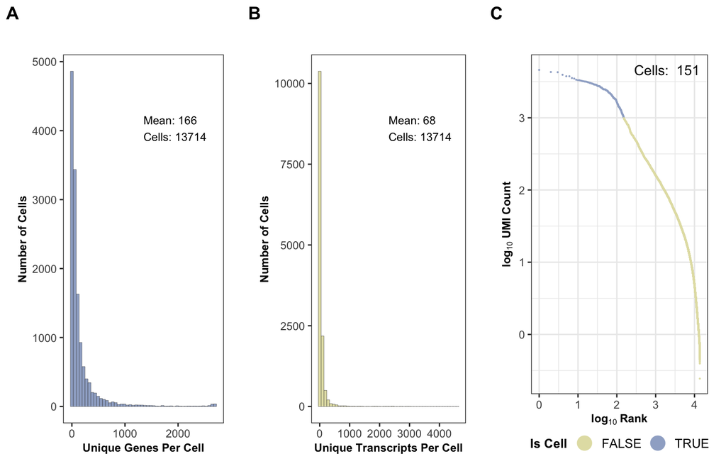

```r
my_colors <- list(lightblue = "#9FAFCD",
                 yellow = "#E3E0B2")

scale_color_two <- function(..., values = c(my_colors$yellow, my_colors$lightblue))
  scale_color_manual(..., values = values)

rel_text <- function(l, x = 0.5, y = 0.8, fontface = 'plain', fontsize = '9', hjust = 0) {
  grob <- grobTree(textGrob(l,
                            x = x,
                            y = y,
                            hjust = hjust,
                            gp = gpar(fontsize=fontsize, fontface=fontface)))
  annotation_custom(grob)
}

my_theme <- theme_bw() +
  theme(axis.title = element_text(face = 2, size=9),
        strip.background = element_blank(),
        strip.text = element_text(face = 2, size = 10),
        legend.text = element_text(size=10),
        legend.title = element_text(face = 2, size=10),
        legend.position = "bottom",
        legend.margin=margin(0,0,0,0),
        legend.box.margin=margin(-7,0,0,0),
        plot.margin = margin(3, 1, 0, 1, "lines"))

my_theme_nogrid <- theme(panel.grid = element_blank())

knee_plot <- function(data, rs = NULL, threshold = 1000) {
  if(!length(rs))
    rs <- rowSums(data)
  rs <- sort(rs, decreasing = TRUE)
  gd <- data.frame(x = log10(1:length(rs)),
                   y = log10(rs),
                   color = factor(rs > threshold))
  lab.y <- max(gd$y)
  lab.x <- max(gd$x)
  ggplot(gd, aes(x=x, y=y, color=color)) +
    geom_point(size = 0.1) +
    annotate(geom = "text", hjust = 1,
             label = paste("Cells: ", sum(rs > threshold)),
             x = lab.x,
             y = lab.y) +
    labs(color = "Is Cell") +
    ylab(bquote(bold("log"[10]~"UMI Count"))) +
    xlab(bquote(bold("log"[10]~"Rank"))) +
    scale_color_two() +
    guides(color = guide_legend(override.aes = list(size = 5))) +
    my_theme
}

genes_per_cell <- function(data, gc = NULL, rs = NULL, threshold = 0, bins = 50) {
  if(!length(gc))
    gc <- rowSums(data != 0)
  if(!length(rs))
    rs <- rowSums(data)
  gc <- gc[which(rs > threshold)]
  gd <- data.frame(gc=gc)
  label <- paste0("Mean: ", round(mean(gc)), "\nCells: ", length(gc))


  ggplot(gd, aes(x=gc)) +
    geom_histogram(bins = bins,
                   fill = my_colors$lightblue,
                   color = "#333333",
                   size = 0.1,
                   show.legend = FALSE) +
    xlab("Unique Genes Per Cell") +
    ylab("Number of Cells") +
    rel_text(label) +
    my_theme +
    my_theme_nogrid
}

umis_per_cell <- function(data, rs = NULL, threshold = 0, bins = 50) {
  if(!length(rs))
    rs <- rowSums(data)
  rs <- rs[which(rs > threshold)]
  gd <- data.frame(rs=rs)
  label <- paste0("Mean: ", round(mean(rs)), "\nCells: ", length(rs))

  ggplot(gd, aes(x=rs)) +
    geom_histogram(bins = bins,
                   fill = my_colors$yellow,
                   color = "#333333",
                   size = 0.1,
                   show.legend = FALSE) +
    xlab("Unique Transcripts Per Cell") +
    ylab("Number of Cells") +
    rel_text(label) +
    my_theme +
    my_theme_nogrid
}

a <- genes_per_cell(normalized_counts(cds))
b <- umis_per_cell(normalized_counts(cds))
c <- knee_plot(normalized_counts(cds))
cowplot::plot_grid(a,b,c, nrow=1, labels=c("A", "B", "C"))
```

We can then perform further dimensional reduction and clustering via UMAP.

```r
#Seurat
pbmc <- RunUMAP(pbmc, dims=1:50)

pbmc <- FindNeighbors(pbmc, dims = 1:50)
pbmc <- FindClusters(pbmc, resolution = 0.01)
```

```
## Modularity Optimizer version 1.3.0 by Ludo Waltman and Nees Jan van Eck
##
## Number of nodes: 2700
## Number of edges: 204000
##
## Running Louvain algorithm...
## Maximum modularity in 10 random starts: 0.9941
## Number of communities: 3
## Elapsed time: 0 seconds
```

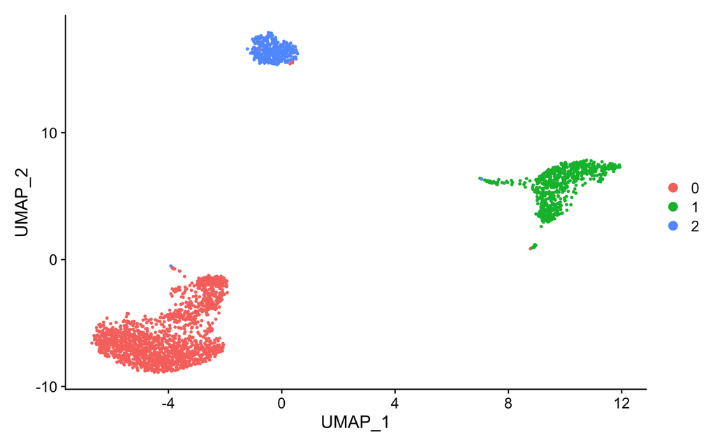

```r
DimPlot(pbmc, reduction = "umap")
```

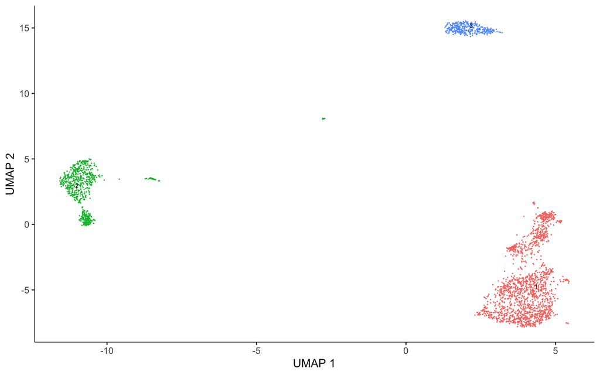

```r
#monocle
cds <- reduce_dimension(cds) # umap by default
cds = cluster_cells(cds, resolution=1e-5)
plot_cells(cds, color_cells_by = "cluster")
```

And perform differential gene expression analysis

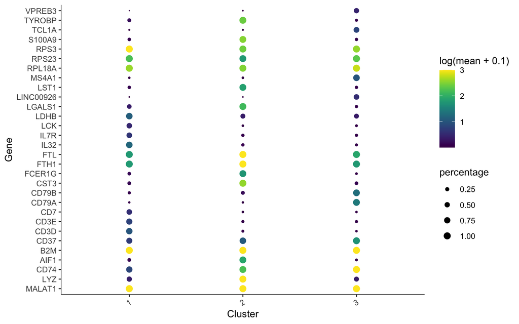

```r
# Seurat
cluster2.markers <- FindMarkers(pbmc, ident.1 = 2, min.pct = 0.25)
head(cluster2.markers, n = 20)

# monocle3

marker_test_res <- top_markers(cds, group_cells_by="cluster",
                               reference_cells=1000, cores=8)

top_specific_markers <- marker_test_res %>%
                            filter(fraction_expressing >= 0.10) %>%
                            group_by(cell_group) %>%
                            top_n(10, pseudo_R2)

top_specific_marker_ids <- unique(top_specific_markers %>% pull(gene_id))
plot_genes_by_group(cds,
                    top_specific_marker_ids,
                    group_cells_by="cluster",
                    ordering_type="maximal_on_diag",
                    max.size=3)
```

Are the genes identified by the two packages the same? Pretty close!

```r
ix <- which(top_specific_markers$cell_group == 3)
cl3_monocle <- top_specific_markers$gene_short_name[ix]

# how many significant genes as defined by Seurat are in top 10
# as defined by monocle?

ix <- which(cluster2.markers$p_val_adj < 0.001)
cl2_seurat <- rownames(cluster2.markers)[ix]
sum(cl3_monocle %in% cl2_seurat)
```

```
## [1] 10
```

```r
# how many of the top 10 most significant genes as defined by Seurat are in
# top 10 as defined by monocle?
ix <- head(order(cluster2.markers$p_val), n=10)
cl2_seurat <- rownames(cluster2.markers)[ix]
sum(cl3_monocle %in% cl2_seurat)
```

```
## [1] 7
```

```r
# 70% ! Not bad!
```

We can also identify genes associated with other metadata we have concerning the cells (diagnosis, outcome, etc.). Here we will classify cells based on gene markers and use those classifications for differential gene expression. (Unfortunately, there seems to be a bug in monocle that is interfering with extraction of the resulting gene level coefficients)

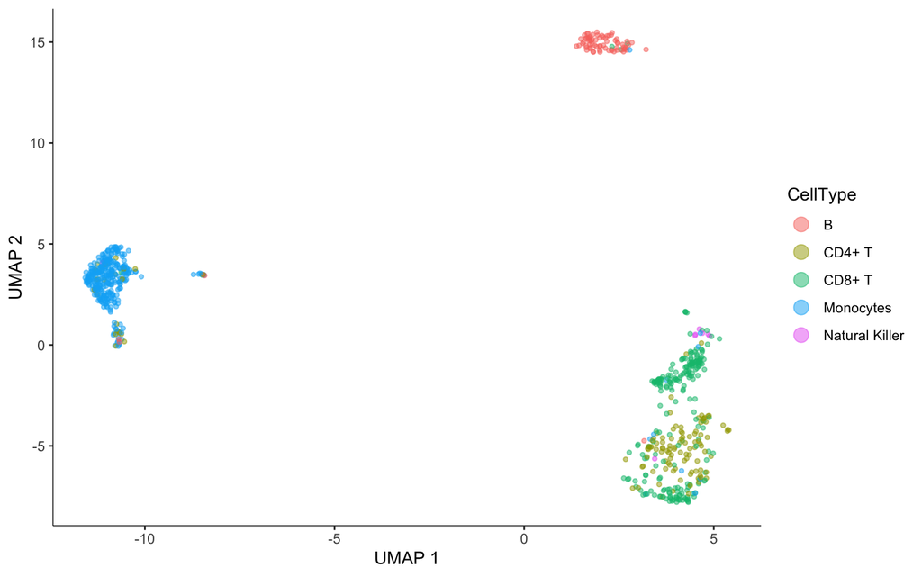

```r
type <- rep("Unknown", ncol(cds))
exp <- normalized_counts(cds)
ix.b <- which(exp["CD3E", ] == 0 & exp["CD19",] > 0)
ix.cd4 <- which(exp["CD3E", ] > 0 & exp["CD4",] > 0)
ix.cd8 <- which(exp["CD3E", ] > 0 & exp["CD8A",] > 0)
ix.nk <- which(exp["CD3E", ] == 0 & exp["NCAM1",] > 0)
ix.mon <- which(exp["CD3E", ] == 0 & exp["CD14",] > 0)
type[ix.b] <- "B"
type[ix.cd4] <- "CD4+ T"
type[ix.cd8] <- "CD8+ T"
type[ix.nk] <- "Natural Killer"
type[ix.mon] <- "Monocytes"
colData(cds)$CellType <- type
ix.unk <- which(type == "Unknown")
plot_cells(cds[ , -ix.unk], color_cells_by = "CellType",
           alpha = 0.5,
           label_cell_groups = FALSE,
           show_trajectory_graph = FALSE,
           cell_size = 1)
```

```r
# gene_fits <- fit_models(cds[ , -ix.unk], model_formula_str = "~ CellType")
#fit_coefs <- coefficient_table(gene_fits)
#fit_coefs %>% filter(term != "(Intercept)") %>%
#      select(gene_short_name, term, q_value, estimate)
```

# 7 Pseudotime

Pseudotime (ordering cells based on their gene expression distance from one another) is a core function of monocle.

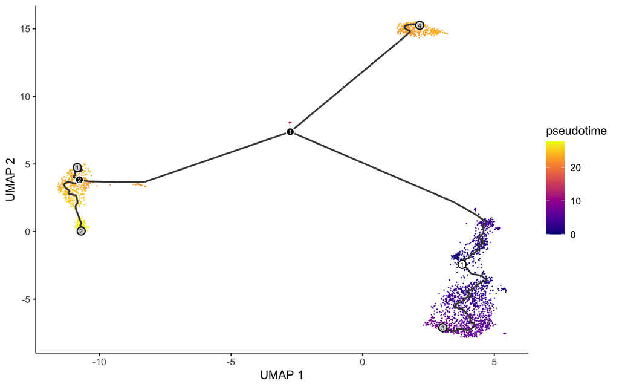

```r
cds <- learn_graph(cds)
cds <- order_cells(cds, root_pr_nodes = "Y_1")
plot_cells(cds,
           color_cells_by = "pseudotime")
```

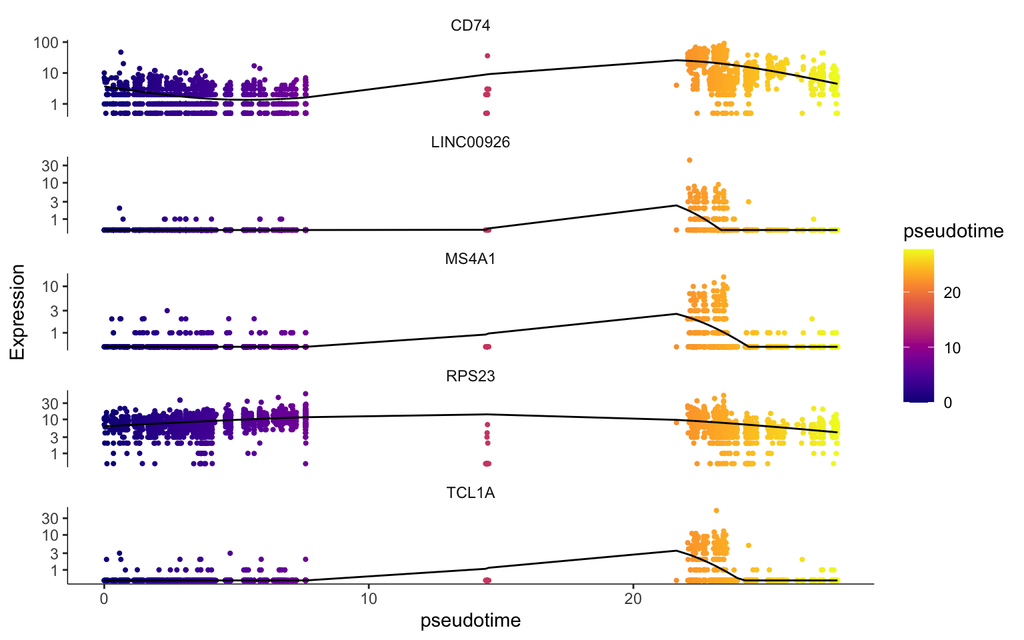

```r
plot_genes_in_pseudotime(cds[cl3_monocle[1:5],], min_expr=0.5)
```

# 8 Further reading

[Seurat demos](https://satijalab.org/seurat/vignettes.html)

[Monocle tutorial](https://cole-trapnell-lab.github.io/monocle3/)

[RNA Velocity Demo](https://combine-lab.github.io/alevin-tutorial/2020/alevin-velocity/)

[RNA Velocity Demo](https://vanandelinstitute.github.io/single_cell_analyses/rnavel_alevin_scvelo.html)

[A real world example](https://github.com/VanAndelInstitute/va_ecls)